# 01_domain_range_basic

## 01_domain_range_basic

#### Question

1. A function $f$ is graphed below.

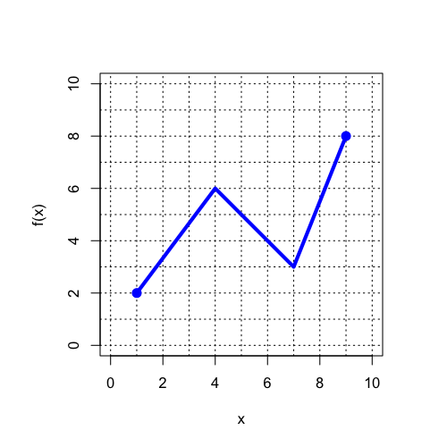

   Determine the [domain](https://en.wikipedia.org/wiki/Domain_of_a_function) and [range](https://en.wikipedia.org/wiki/Range_of_a_function). *Note: wikipedia suggests using “image” instead of “range”.*

   Express your answer using interval notation.

   What is the domain?
   - [, ]

   What is the range?
   - [, ]

#### Question

2. A function $f$ is graphed below.

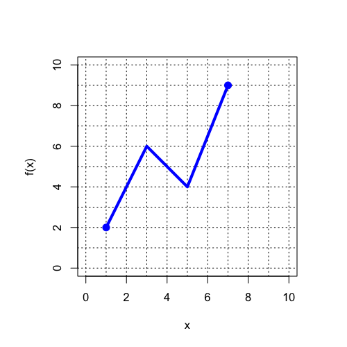

   Determine the [domain](https://en.wikipedia.org/wiki/Domain_of_a_function) and [range](https://en.wikipedia.org/wiki/Range_of_a_function). *Note: wikipedia suggests using “image” instead of “range”.*

   Express your answer using interval notation.

   What is the domain?
   - [, ]

   What is the range?
   - [, ]

#### Question

3. A function $f$ is graphed below.

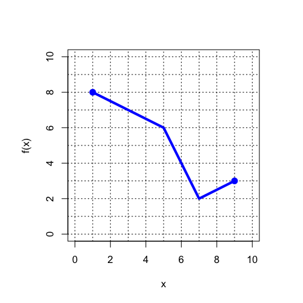

   Determine the [domain](https://en.wikipedia.org/wiki/Domain_of_a_function) and [range](https://en.wikipedia.org/wiki/Range_of_a_function). *Note: wikipedia suggests using “image” instead of “range”.*

   Express your answer using interval notation.

   What is the domain?
   - [, ]

   What is the range?
   - [, ]

#### Question

4. A function $f$ is graphed below.

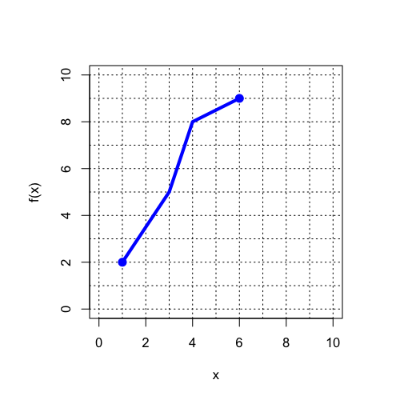

   Determine the [domain](https://en.wikipedia.org/wiki/Domain_of_a_function) and [range](https://en.wikipedia.org/wiki/Range_of_a_function). *Note: wikipedia suggests using “image” instead of “range”.*

   Express your answer using interval notation.

   What is the domain?
   - [, ]

   What is the range?
   - [, ]

#### Question

5. A function $f$ is graphed below.

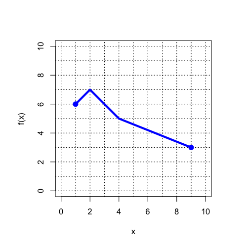

   Determine the [domain](https://en.wikipedia.org/wiki/Domain_of_a_function) and [range](https://en.wikipedia.org/wiki/Range_of_a_function). *Note: wikipedia suggests using “image” instead of “range”.*

   Express your answer using interval notation.

   What is the domain?
   - [, ]

   What is the range?
   - [, ]

#### Question

6. A function $f$ is graphed below.

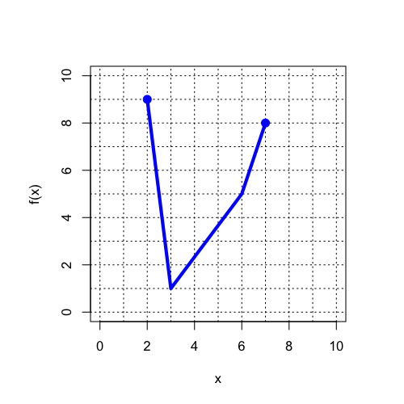

   Determine the [domain](https://en.wikipedia.org/wiki/Domain_of_a_function) and [range](https://en.wikipedia.org/wiki/Range_of_a_function). *Note: wikipedia suggests using “image” instead of “range”.*

   Express your answer using interval notation.

   What is the domain?
   - [, ]

   What is the range?
   - [, ]

#### Question

7. A function $f$ is graphed below.

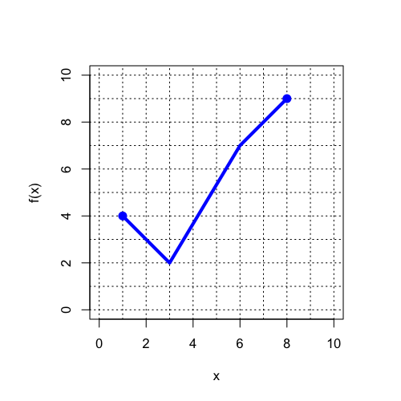

   Determine the [domain](https://en.wikipedia.org/wiki/Domain_of_a_function) and [range](https://en.wikipedia.org/wiki/Range_of_a_function). *Note: wikipedia suggests using “image” instead of “range”.*

   Express your answer using interval notation.

   What is the domain?
   - [, ]

   What is the range?
   - [, ]

#### Question

8. A function $f$ is graphed below.

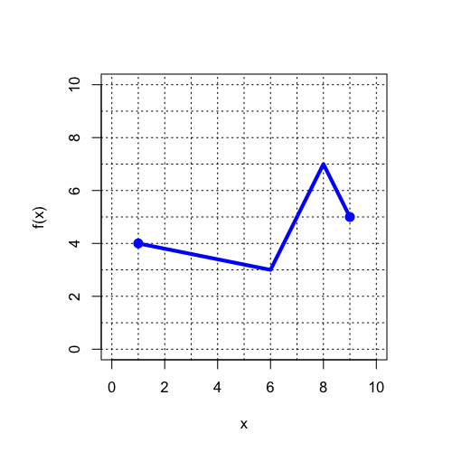

   Determine the [domain](https://en.wikipedia.org/wiki/Domain_of_a_function) and [range](https://en.wikipedia.org/wiki/Range_of_a_function). *Note: wikipedia suggests using “image” instead of “range”.*

   Express your answer using interval notation.

   What is the domain?
   - [, ]

   What is the range?
   - [, ]

#### Question

9. A function $f$ is graphed below.

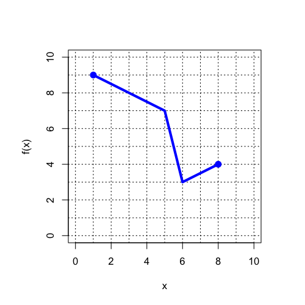

   Determine the [domain](https://en.wikipedia.org/wiki/Domain_of_a_function) and [range](https://en.wikipedia.org/wiki/Range_of_a_function). *Note: wikipedia suggests using “image” instead of “range”.*

   Express your answer using interval notation.

   What is the domain?
   - [, ]

   What is the range?
   - [, ]

#### Question

10. A function $f$ is graphed below.

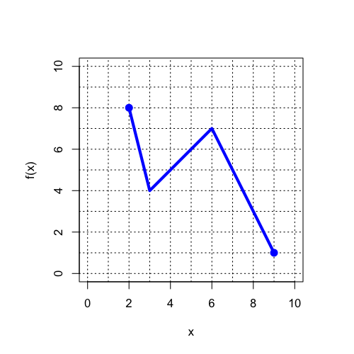

    Determine the [domain](https://en.wikipedia.org/wiki/Domain_of_a_function) and [range](https://en.wikipedia.org/wiki/Range_of_a_function). *Note: wikipedia suggests using “image” instead of “range”.*

    Express your answer using interval notation.

    What is the domain?
    - [, ]

    What is the range?
    - [, ]

#### Question

11. A function $f$ is graphed below.

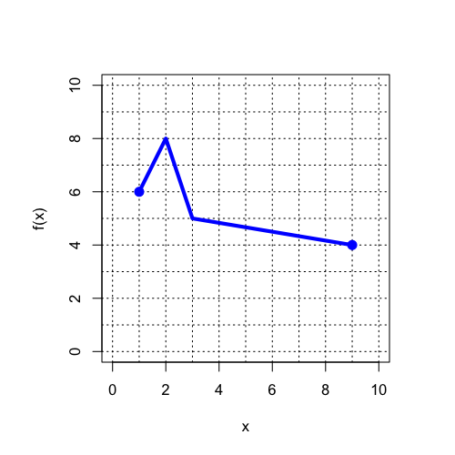

    Determine the [domain](https://en.wikipedia.org/wiki/Domain_of_a_function) and [range](https://en.wikipedia.org/wiki/Range_of_a_function). *Note: wikipedia suggests using “image” instead of “range”.*

    Express your answer using interval notation.

    What is the domain?
    - [, ]

    What is the range?
    - [, ]

#### Question

12. A function $f$ is graphed below.

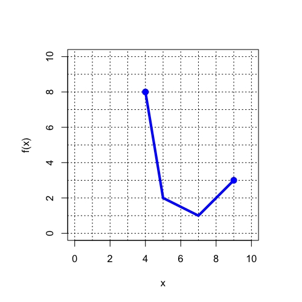

    Determine the [domain](https://en.wikipedia.org/wiki/Domain_of_a_function) and [range](https://en.wikipedia.org/wiki/Range_of_a_function). *Note: wikipedia suggests using “image” instead of “range”.*

    Express your answer using interval notation.

    What is the domain?
    - [, ]

    What is the range?
    - [, ]